# Homework2

## Introduction to Statistical Learning with R, second edition

Section 2.4

Question 8 :

```r
college <- read.csv("College.csv")
view(college)
```

… We still need to eliminate the first column in the data where the names are stored.

I tried to do this with the function below,

college <- read_csv(“https://www.statlearning.com/s/College.csv”) %>% select(-1)

The book’s alternative:

```r
rownames(college) <- college[,1]
view(college)
```

```r
college <- college[, -1]
view(college)
```

Use the summary() function to produce a numerical summary of the variables in the data set.

```r
summary(college)
```

```
##    Private               Apps           Accept          Enroll
##  Length:777         Min.   :   81   Min.   :   72   Min.   :  35
##  Class :character   1st Qu.:  776   1st Qu.:  604   1st Qu.: 242
##  Mode  :character   Median : 1558   Median : 1110   Median : 434
##                     Mean   : 3002   Mean   : 2019   Mean   : 780
##                     3rd Qu.: 3624   3rd Qu.: 2424   3rd Qu.: 902
##                     Max.   :48094   Max.   :26330   Max.   :6392
##    Top10perc       Top25perc      F.Undergrad     P.Undergrad
##  Min.   : 1.00   Min.   :  9.0   Min.   :  139   Min.   :    1.0
##  1st Qu.:15.00   1st Qu.: 41.0   1st Qu.:  992   1st Qu.:   95.0
##  Median :23.00   Median : 54.0   Median : 1707   Median :  353.0
##  Mean   :27.56   Mean   : 55.8   Mean   : 3700   Mean   :  855.3
##  3rd Qu.:35.00   3rd Qu.: 69.0   3rd Qu.: 4005   3rd Qu.:  967.0
##  Max.   :96.00   Max.   :100.0   Max.   :31643   Max.   :21836.0
##     Outstate       Room.Board       Books           Personal
##  Min.   : 2340   Min.   :1780   Min.   :  96.0   Min.   : 250
##  1st Qu.: 7320   1st Qu.:3597   1st Qu.: 470.0   1st Qu.: 850
##  Median : 9990   Median :4200   Median : 500.0   Median :1200
##  Mean   :10441   Mean   :4358   Mean   : 549.4   Mean   :1341
##  3rd Qu.:12925   3rd Qu.:5050   3rd Qu.: 600.0   3rd Qu.:1700
##  Max.   :21700   Max.   :8124   Max.   :2340.0   Max.   :6800
##       PhD            Terminal       S.F.Ratio      perc.alumni
##  Min.   :  8.00   Min.   : 24.0   Min.   : 2.50   Min.   : 0.00
##  1st Qu.: 62.00   1st Qu.: 71.0   1st Qu.:11.50   1st Qu.:13.00
##  Median : 75.00   Median : 82.0   Median :13.60   Median :21.00
##  Mean   : 72.66   Mean   : 79.7   Mean   :14.09   Mean   :22.74
##  3rd Qu.: 85.00   3rd Qu.: 92.0   3rd Qu.:16.50   3rd Qu.:31.00
##  Max.   :103.00   Max.   :100.0   Max.   :39.80   Max.   :64.00
##      Expend        Grad.Rate
##  Min.   : 3186   Min.   : 10.00
##  1st Qu.: 6751   1st Qu.: 53.00
##  Median : 8377   Median : 65.00
##  Mean   : 9660   Mean   : 65.46
##  3rd Qu.:10830   3rd Qu.: 78.00
##  Max.   :56233   Max.   :118.00
```

Use the pairs() function to produce a scatterplot matrix of the first ten columns or variables of the data. Recall that you can reference the first ten columns of a matrix A using A[,1:10].

- I got en error saying “Error in pairs.default(college[, 1:10]) : non-numeric argument to ‘pairs’”. So that’s why I used pairs(college[, 2:10]).

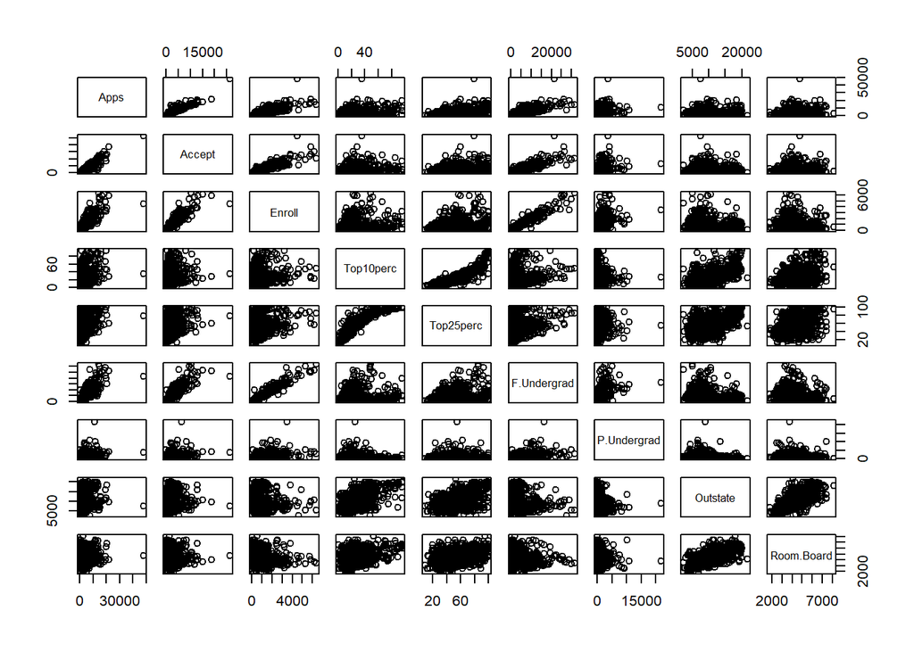

```r
pairs(college[, 2:10])
```

Use the plot() function to produce side-by-side boxplots of Outstate versus Private.

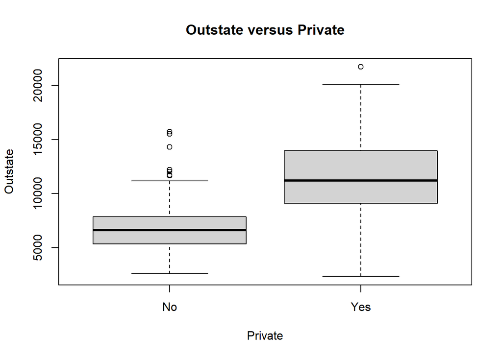

```r
boxplot(college$Outstate ~ college$Private, main = "Outstate versus Private",
    xlab = "Private", ylab = "Outstate")
```

Create a new qualitative variable, called Elite, by binning the Top10perc variable. We are going to divide universities into two groups based on whether or not the proportion of students coming from the top 10% of their high school classes exceeds 50 %.

```r
Elite <- rep("No", nrow(college))
Elite[college$Top10perc > 50] <- "Yes"
Elite <- as.factor(Elite)
college <- data.frame(college , Elite)
```

Use the summary() function to see how many elite universities there are.

```r
summary(college$Elite)
```

```
##  No Yes
## 699  78
```

Now use the plot() function to produce side-by-side boxplots of Outstate versus Elite.

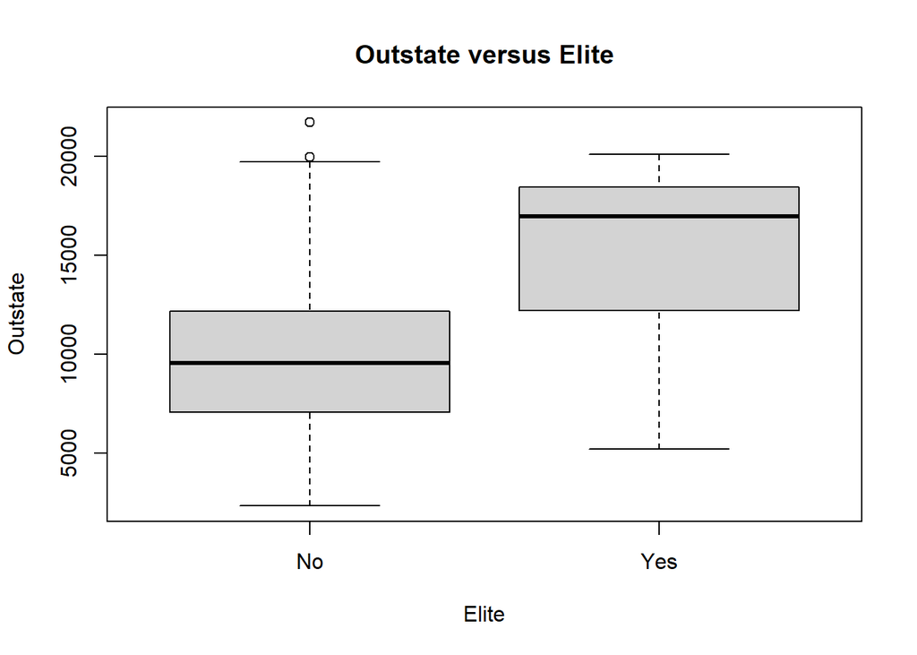

```r
boxplot(college$Outstate ~ college$Elite, main = "Outstate versus Elite",
    xlab = "Elite", ylab = "Outstate")
```

Use the hist() function to produce some histograms with differing numbers of bins for a few of the quantitative variables. You may find the command par(mfrow = c(2, 2)) useful: it will divide the print window into four regions so that four plots can be made simultaneously. Modifying the arguments to this function will divide the screen in other ways.

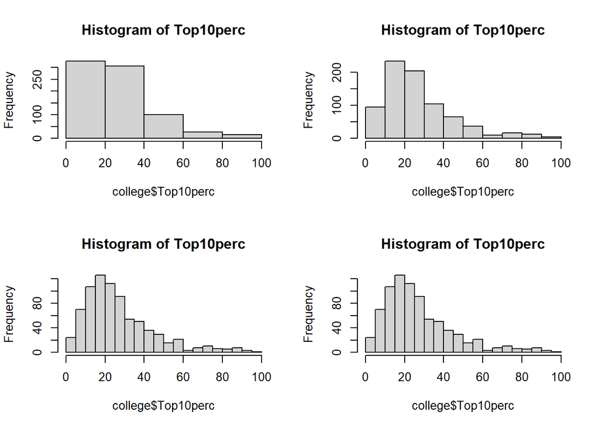

```r
par(mfrow = c(2, 2))
hist(college$Top10perc, breaks = 5, main="Histogram of Top10perc")
hist(college$Top10perc, breaks = 10, main="Histogram of Top10perc")
hist(college$Top10perc, breaks = 15, main="Histogram of Top10perc")
hist(college$Top10perc, breaks = 20, main="Histogram of Top10perc")
```

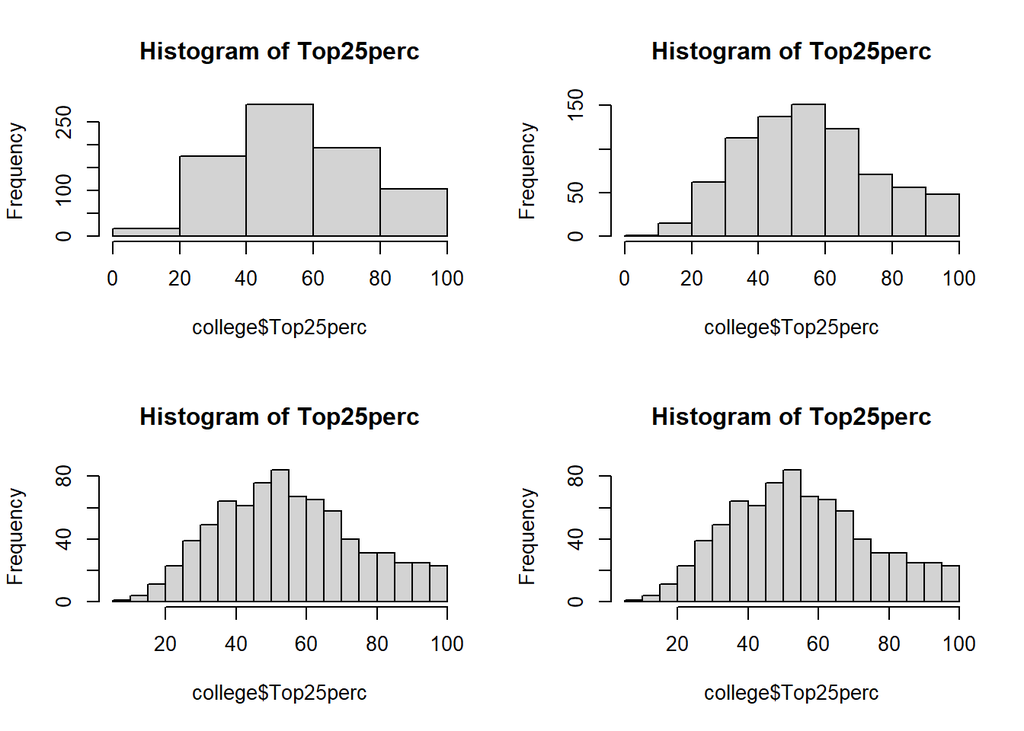

```r
par(mfrow = c(2, 2))
hist(college$Top25perc, breaks = 5, main="Histogram of Top25perc")
hist(college$Top25perc, breaks = 10, main="Histogram of Top25perc")
hist(college$Top25perc, breaks = 15, main="Histogram of Top25perc")
hist(college$Top25perc, breaks = 20, main="Histogram of Top25perc")
```

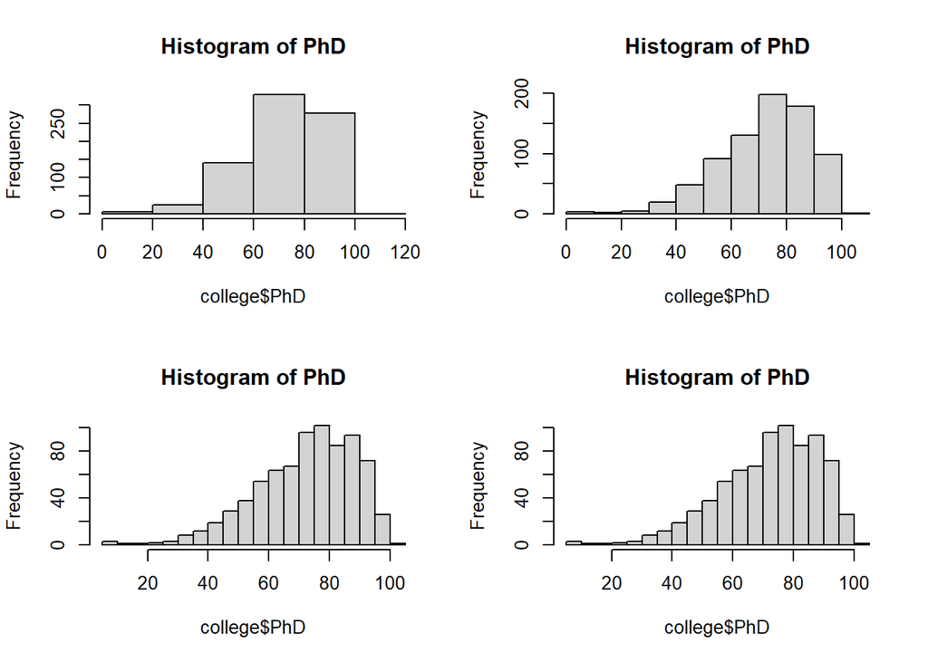

```r
par(mfrow = c(2, 2))
hist(college$PhD, breaks = 5, main="Histogram of PhD")
hist(college$PhD, breaks = 10, main="Histogram of PhD")
hist(college$PhD, breaks = 15, main="Histogram of PhD")
hist(college$PhD, breaks = 20, main="Histogram of PhD")
```

Continue exploring the data, and provide a brief summary of what you discover.

```r
summary(college$PhD)
```

```
##    Min. 1st Qu.  Median    Mean 3rd Qu.    Max.
##    8.00   62.00   75.00   72.66   85.00  103.00
```

```r
summary(college$F.Undergrad)
```

```
##    Min. 1st Qu.  Median    Mean 3rd Qu.    Max.
##     139     992    1707    3700    4005   31643
```

```r
summary(college$perc.alumni)
```

```
##    Min. 1st Qu.  Median    Mean 3rd Qu.    Max.
##    0.00   13.00   21.00   22.74   31.00   64.00
```

```r
row.names(college[college$Outstate>20000, ])
```

```
## [1] "Bennington College"
## [2] "Massachusetts Institute of Technology"
```

Question 9 :

```r
auto <- read.table("Auto.data")
auto <- read.table("Auto.data",header=TRUE,na.strings ="?")
auto = na.omit(auto)
view(auto)
```

Which of the predictors are quantitative, and which are qualitative?

```r
names(auto)
```

```
## [1] "mpg"          "cylinders"    "displacement" "horsepower"   "weight"
## [6] "acceleration" "year"         "origin"       "name"
```

```r
?Auto
```

```
## starting httpd help server ... done
```

Name and origin are qualitative, the rest of the predictors are quantitative.

What is the range of each quantitative predictor? You can answer this using the range() function.

```r
range(auto$mpg)
```

```
## [1]  9.0 46.6
```

```r
range(auto$cylinders)
```

```
## [1] 3 8
```

```r
range(auto$displacement)
```

```
## [1]  68 455
```

```r
auto$horsepower <- as.numeric(auto$horsepower )
t(sapply(auto[,1:7],range))
```

```
##              [,1]   [,2]
## mpg             9   46.6
## cylinders       3    8.0
## displacement   68  455.0
## horsepower     46  230.0
## weight       1613 5140.0
## acceleration    8   24.8
## year           70   82.0
```

What is the mean and standard deviation of each quantitative predictor?

```r
colMeans(auto[, 1:7], na.rm = FALSE)
```

```
##          mpg    cylinders displacement   horsepower       weight acceleration
##    23.445918     5.471939   194.411990   104.469388  2977.584184    15.541327
##         year
##    75.979592
```

```r
sapply(auto[, 1:7], sd)
```

```
##          mpg    cylinders displacement   horsepower       weight acceleration
##     7.805007     1.705783   104.644004    38.491160   849.402560     2.758864
##         year
##     3.683737
```

Now remove the 10th through 85th observations. What is the range, mean, and standard deviation of each predictor in the subset of the data that remains?

```r
apply(auto[-c(10:85),1:7], 2, range)
```

```
##       mpg cylinders displacement horsepower weight acceleration year
## [1,] 11.0         3           68         46   1649          8.5   70
## [2,] 46.6         8          455        230   4997         24.8   82
```

```r
apply(auto[-c(10:85),1:7], 2, mean)
```

```
##          mpg    cylinders displacement   horsepower       weight acceleration
##    24.404430     5.373418   187.240506   100.721519  2935.971519    15.726899
##         year
##    77.145570
```

```r
apply(auto[-c(10:85),1:7], 2, sd)
```

```
##          mpg    cylinders displacement   horsepower       weight acceleration
##     7.867283     1.654179    99.678367    35.708853   811.300208     2.693721
##         year
##     3.106217
```

Using the full data set, investigate the predictors graphically, using scatterplots or other tools of your choice. Create some plots highlighting the relationships among the predictors.

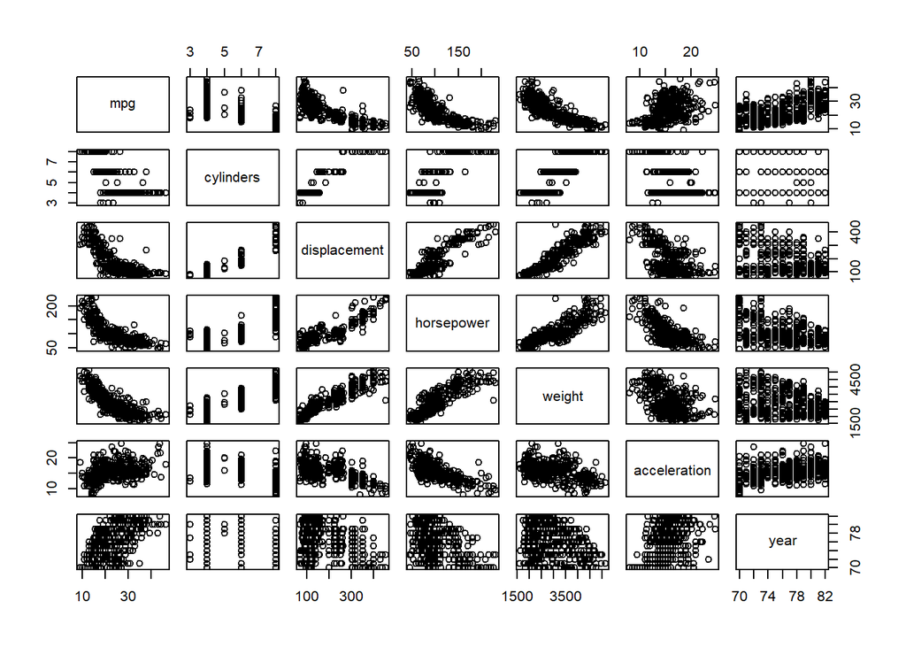

```r
pairs(Auto[,1:7])
```

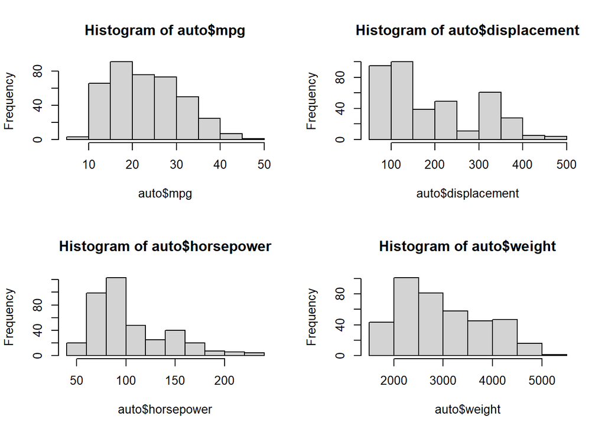

```r
par(mfrow=c(2,2))
hist(auto$mpg)
hist(auto$displacement)
hist(auto$horsepower)
hist(auto$weight)
```

Suppose that we wish to predict gas mileage (mpg) on the basis of the other variables. Do your plots suggest that any of the other variables might be useful in predicting mpg? Justify your answer.

- My answer: Yes. In the plot we obtained by running pairs(Auto[,1:7]) function, we see that variables have positive or negative relations with the mpg result.

For example year and mpg or acceleration and mpg appear to have a positive relation, while displacement and mpg or weight and mpg appear to have a negative relationship. Therefore, other variables can be useful in predicting mpg.

Question 10:

```r
?Boston
```

Description: A data set containing housing values in 506 suburbs of Boston.

Format: A data frame with 506 rows and 13 variables.

crim : per capita crime rate by town.

zn : proportion of residential land zoned for lots over 25,000 sq.ft.

indus : proportion of non-retail business acres per town.

chas : Charles River dummy variable (= 1 if tract bounds river; 0 otherwise).

nox : nitrogen oxides concentration (parts per 10 million).

rm : average number of rooms per dwelling.

age : proportion of owner-occupied units built prior to 1940.

dis : weighted mean of distances to five Boston employment centres.

rad : index of accessibility to radial highways.

tax : full-value property-tax rate per $10,000.

ptratio : pupil-teacher ratio by town.

lstat : lower status of the population (percent).

medv : median value of owner-occupied homes in $1000s.

Make some pairwise scatterplots of the predictors (columns) in this data set.

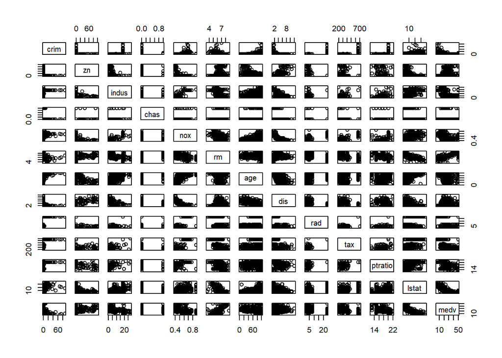

```r
pairs(Boston)
```

Are any of the predictors associated with per capita crime rate? If so, explain the relationship.

Do any of the census tracts of Boston appear to have particularly high crime rates? Tax rates? Pupil-teacher ratios? Comment on the range of each predictor

```r
summary(Boston$crim)
```

```
##     Min.  1st Qu.   Median     Mean  3rd Qu.     Max.
##  0.00632  0.08204  0.25651  3.61352  3.67708 88.97620
```

```r
summary(Boston$tax)
```

```
##    Min. 1st Qu.  Median    Mean 3rd Qu.    Max.
##   187.0   279.0   330.0   408.2   666.0   711.0
```

How many of the census tracts in this data set bound the Charles river?

```r
nrow(subset(Boston, chas ==1))
```

```
## [1] 35
```

What is the median pupil-teacher ratio among the towns in this data set?

```r
summary(Boston$ptratio)
```

```
##    Min. 1st Qu.  Median    Mean 3rd Qu.    Max.
##   12.60   17.40   19.05   18.46   20.20   22.00
```

19 pupils for each teacher